# Examining the Canned Tuna Competitive Landscape

### Price elasticity modelling

#### Simple linear models

In the modelling section, I’ll develop linear models for each brand where sales is the outcome variable and price is the predictor. In this model, both variables will be log transformed so it will be a logarithmic pricing model. To ensure each model’s components can be reviewed at once, I’ve developed a function that creates each linear regression and collects summary statistics. Using this in conjunction with `map2`, I’ve created a data frame with all the estimated model components.

I’ve also included the adjusted R squared for each model. This provides insight into how much sales variance explained by price. Some of the bigger brands– like Starkist, Chicken of the Sea– as well Geisha have variance explanation for one term models. For these, price explains about half the sales variance, which is fairly large for a single predictor. The largest adjusted R squared is for Bumble Bee chunk at almost 60%. However, price explains almost no sales variance for Bumble Bee large and very little for the Bumble Bee solid. All considered, the adjusted R squared results also don’t conform to the price volume split, though most of the high volume brands have high variance explanations.

```r
tuna_lm_summary <- function(move, price){
  tuna_y <- tuna_brands %>%
    select(move)

  tuna_x <- tuna_brands %>%
    select(price)

  sales_lm <- lm(log(tuna_y[,1]) ~ tuna_x[,1])

  lm_summary <- summary(sales_lm)$coefficients[2,] %>%
    t() %>%
    as.data.frame()

  lm_summary <- lm_summary %>%
    mutate(adj_rsq = summary(sales_lm)$adj.r.squared) %>%
    rename(elasticity = Estimate) %>%
    rename_all(tolower)

  return(lm_summary)
}

move_cols <- c(2, 3, 4, 5, 6, 7, 8)

price_cols <- c(10, 11, 12, 13, 14, 15, 16)

lm_summaries <- map2_df(.x = move_cols, .y = price_cols, function(x, y)
  tuna_lm_summary(move = x, price = y)) %>%
  mutate(brand = brand_names) %>%
  select(brand, everything())

lm_summaries %>%
  custom_kable()
```

| brand | elasticity | std. error | t value | pr(>\|t\|) | adj_rsq |
| --- | --- | --- | --- | --- | --- |
| starkist | -3.920561 | 0.2141534 | -18.307257 | 0.0000000 | 0.4978810 |
| cs | -4.795228 | 0.2407967 | -19.914010 | 0.0000000 | 0.5399743 |
| bb_solid | -5.754999 | 0.9387366 | -6.130579 | 0.0000000 | 0.0979271 |
| bb_chunk | -4.355735 | 0.1952376 | -22.309918 | 0.0000000 | 0.5957936 |
| geisha | -5.308389 | 0.2735582 | -19.404973 | 0.0000000 | 0.5270527 |
| bb_large | -2.696835 | 1.1425233 | -2.360420 | 0.0188251 | 0.0133840 |
| hh_chunk | -3.118610 | 0.3203380 | -9.735371 | 0.0000000 | 0.2176935 |

#### Multivariate logarithmic pricing models

The multivariate pricing models are an extension of the initial linear models. The model coefficients here are cross elasticities though, which help reveal how a specific brand’s sales change with price changes across all brands. I’ve also taken the same approach to developing these models by creating a function to run each at the same time.

Prior to reviewing the result, it’s worth spending time on how to interpret the cross elasticities. Since both the outcome and predictors have been log transformed, the regression coefficients indicate percentage changes. Specifically, this means that for every unit increase in a brand price, brand sales change by a certain percent. With this in mind, I’ve visualized all the multivariate model coefficients below and provided some initial commentary:

##### HH Chunk

This modelling work reinforces the high volume, low cost competitive space. Starkist seems to be the top brand here given it has significant positive cross elasticities for the next three competitors in the space. For example, a percentage rise in Starkist prices results in about 1.19% added sales for Chicken of the Sea. I think this indicates that if the brand increases prices, consumers look at another low cost brand but otherwise, stay with Starkist. The lower value group shows less conclusive results.

Perhaps the most sclerotic cross elasticity can be found in the HH chunk model. There is a large negative cross elasticity which indicates that a percentage rise in the Bumble Bee large price results in a sales decline of about 4.32% for HH chunk. The value is larger than it’s own price elasticity in the model, which is not intuitive.

This highlights one of the main limitations of these models: the coefficients can change signs when aggregated. While each model’s own elasticity remained interpretable, the cross elasticity interpretation are contrary to the basic ideas of consumer behaviour.

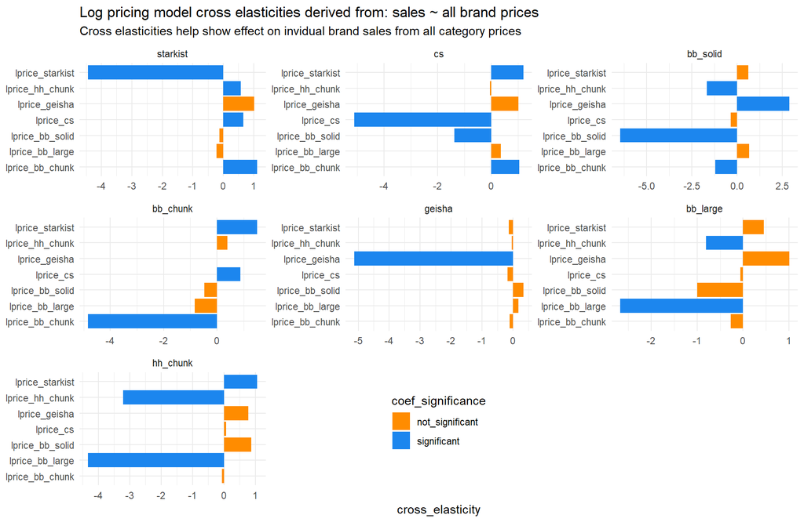

```r
tuna_cross_elasticities <- function(tuna_brand, num){
  tuna_y <- tuna %>%
    select(tuna_brand) %>%
    mutate_all(function(x) log(x))

  cross_elasticities <- tuna_brands %>%
    select(10:16) %>%
    lm(tuna_y[,1] ~ ., data = .) %>%
    summary() %>%
    coefficients() %>%
    as.data.frame() %>%
    rownames_to_column(var = "variable") %>%
    rename(cross_elasticity = Estimate,
           coef_pvalue = "Pr(>|t|)") %>%
    mutate(brand = brand_names[num],
           coef_significance = ifelse(coef_pvalue < .05,
                                      "significant", "not_significant")) %>%
    select(brand, everything())
}

map2_df(names(tuna)[2:8], c(1:7), function(x, y)
  tuna_cross_elasticities(tuna_brand = x, num = y)) %>%
  filter(variable != "(Intercept)") %>%
  mutate(brand = factor(brand, levels = brand_names)) %>%
  ggplot(aes(variable, cross_elasticity, fill = coef_significance)) +
  geom_col() +
  facet_wrap(facets = "brand", scales = "free") +
  coord_flip() +
  scale_fill_manual(values = c("darkorange", "dodgerblue2")) +
  theme(legend.position = c(0.5, 0.15)) +
  labs(title = "Log pricing model cross elasticities derived from: sales ~ all brand prices",
       subtitle = "Cross elasticities help show effect on invidual brand sales from all category prices",
       x = NULL)
```

The model’s I developed also are limited because they have constant elasticities, which implies that these effects are uniform across the series. To review how these look at different points in the time series, I redeveloped the previous cross elasticity function to allow model development in different windows.

Essentially, the function fits a model for the first year and a half (from week 1 to 78) and then slowly moves through the series with this window until week 338. The approach yields 261 models that can be individually analyzed to understand how the cross elasticities change over time. While this doesn’t negate time, the models, when taken together, at least show the dynamic changes in brand sales and prices. The plot below visualizes these changes.

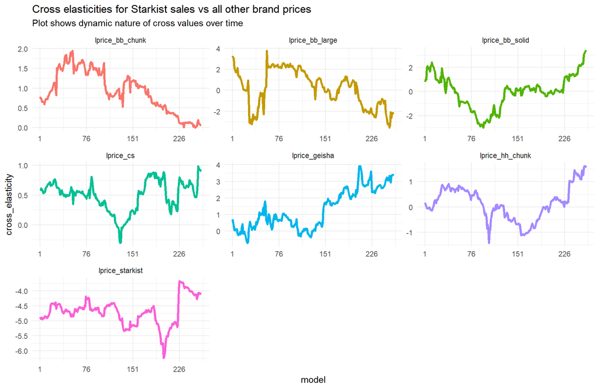

```r
tuna_cross_elasticities <- function(tuna_brand, start, end){
  tuna_y <- tuna %>%
    select(tuna_brand) %>%
    mutate_all(function(x) log(x))

  lm_set <- tuna_brands %>%
    mutate(y = tuna_y[,1]) %>%
    select(10:17)

  cross_lm <- lm(y ~ ., data = lm_set[start:end,])

  cross_coef <- summary(cross_lm)$coefficients %>%
    as.data.frame() %>%
    rownames_to_column(var = "variable") %>%
    rename(cross_elasticity = Estimate,
           coef_pvalue = "Pr(>|t|)") %>%
    mutate(brand = tuna_brand,
           model = rep(start, times = 8)) %>%
    filter(variable != "(Intercept)") %>%
    mutate(coef_significance = ifelse(coef_pvalue < .05,
                                      "significant", "not_significant")) %>%
    select(brand, model, everything())

    return(cross_coef)
}

start_period <- seq(1, nrow(tuna) - 77, 1)

end_period <- seq(78, nrow(tuna), 1)

rolling_tuna_crosses <- map_df(.x = 2:8, function(z)
  map2_df(
    .x = start_period, .y = end_period, function(x, y)
    tuna_cross_elasticities(tuna_brand = names(tuna)[z],
                            start = x,
                            end = y)
    )
) %>% mutate(brand = rep(brand_names, each = length(start_period) *
                           length(brand_names)),
             brand = factor(brand, levels = brand_names))

rolling_tuna_crosses %>%
  filter(brand == "starkist") %>%
  ggplot(aes(model, cross_elasticity, colour = variable)) +
  geom_line(size = 1.3, show.legend = F) +
  facet_wrap(facets = "variable", scales = "free") +
  scale_x_continuous(breaks = seq(1, 400, 75)) +
  labs(title = "Cross elasticities for Starkist sales vs all other brand prices",
       subtitle = "Plot shows dynamic nature of cross values over time")
```

To get a more aggregate picture of the cross elasticities, I’ve taken the median values for both brand sales and price using `group_by`. Following this, I’ve added in coefficient significance percentages. The approach seems to clean up some of the contradictory, positive cross elasticities. Moreover, the remaining ones have a quantified significance colouring so they can be assessed more clearly.

An interesting trend here is Geisha being the recipient of customers from the low cost brands during price increases. Looking at Chicken of the Sea, Geisha sees around 2% sales increase during a percentage raise for the brand. Similar trends can be seen for Starkist, Bumble Bee solid, and Bumble Bee large. It seems consumers might choose the brand during periods when the low cost options aren’t being offered on special. For Bumble Bee large, it might just be consumers in the same high cost space.

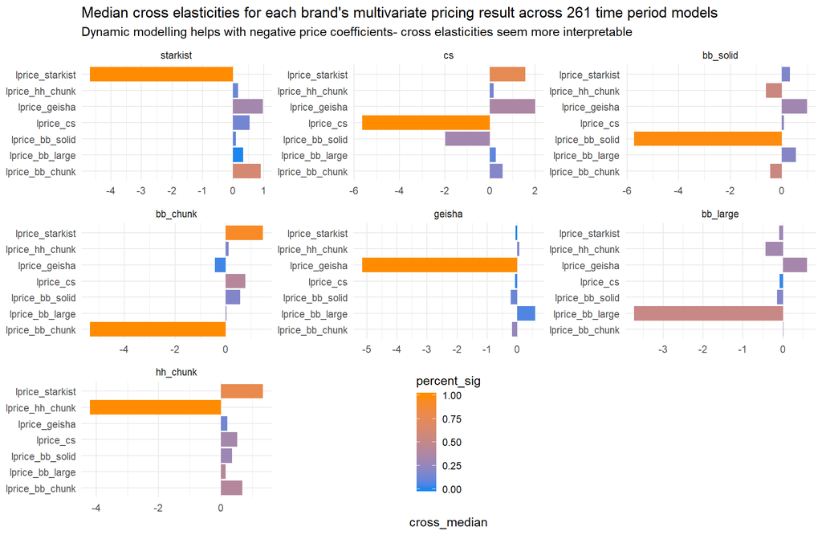

```r
rolling_cross_coefs <- rolling_tuna_crosses %>%
  group_by(brand, variable) %>%
  summarise(cross_median = median(cross_elasticity))

rolling_cross_coefs <- rolling_tuna_crosses %>%
  count(brand, variable, coef_significance) %>%
  filter(coef_significance == "significant") %>%
  mutate(percent_sig = n / length(start_period)) %>%
  right_join(x = ., y = rolling_cross_coefs, by = c("brand", "variable")) %>%
  select(-n) %>%
  mutate(percent_sig = ifelse(is.na(percent_sig), 0, percent_sig))

rolling_cross_coefs %>%
  ggplot(aes(variable, cross_median, fill = percent_sig)) +
  geom_col() +
  facet_wrap(facets = "brand", scales = "free") +
  coord_flip() +
  scale_fill_gradient(low = "dodgerblue2", high = "darkorange") +
  theme(legend.position = c(0.5, 0.15)) +
  labs(title = "Median cross elasticities for each brand's multivariate pricing result across 261 time period models",
       subtitle = "Dynamic modelling helps with negative price coefficients- cross elasticities seem more interpretable",
       x = NULL)
```

#### Multivariate category sales models

The next model to consider is the log transformed total category sales as the outcome with log prices as the predictors. I’ve started be developing the full linear model. The coefficients for both Geisha and Bumble Bee large now show positive percentage increases. This seems unlikely given tuna is almost certainly not a Giffen good. This plausibly could be because there’s increased demand, resulting in higher sales, alongside a price increase. That said, there wasn’t any major upward sales trend for either of these brands, although the large cans did have a slight increase.

Instead, the results highlight that each brand has a very different volume and price coefficient when viewed individually than when aggregated. This is an example of Simpson’s Paradox, also called the Yule-Simpson effect, whereby a trend or relationship that is observed within a group reverses when the groups are combined (Berman et. al, 2012). The effect arises due to a confounding variable which skews the overall results.

Here, I think time is the confounding variable because there are different macroeconomic and marketing activities shaping the price and volume relationship over the series. This outside knowledge helps put the results in perspective. After seeing this summary, the cross elasticities seem hard to trust. Again, the regression approach doesn’t pick up the time interaction well so the model interpretation suffers. This effect hinders both multivariate approaches.

The inherent confounding effect of time limits the linear model cross elasticities. As a result of this, I wanted to try and evaluate how these coefficients changed at different points in the series so the time component could be better understood. To do this, I developed a function to take the multivariate log pricing model on a rolling basis across the time series.

```r
tuna_brands <- tuna_brands %>%
  mutate(log_sales = log(total_sales))

tuna_sales_lm <- lm(log_sales ~ lprice_starkist + lprice_cs +
                      lprice_bb_solid + lprice_bb_chunk + lprice_geisha +
                      lprice_bb_large + lprice_hh_chunk,
                    data = tuna_brands)

summary(tuna_sales_lm)
```

```
##
## Call:
## lm(formula = log_sales ~ lprice_starkist + lprice_cs + lprice_bb_solid +
##     lprice_bb_chunk + lprice_geisha + lprice_bb_large + lprice_hh_chunk,
##     data = tuna_brands)
##
## Residuals:
##     Min      1Q  Median      3Q     Max
## -0.7665 -0.2993 -0.1098  0.1611  2.1614
##
## Coefficients:
##                 Estimate Std. Error t value Pr(>|t|)
## (Intercept)      10.0920     1.1913   8.471 8.14e-16 ***
## lprice_starkist  -0.7387     0.2010  -3.676 0.000277 ***
## lprice_cs        -1.2810     0.2011  -6.371 6.30e-10 ***
## lprice_bb_solid  -1.4714     0.5997  -2.453 0.014667 *
## lprice_bb_chunk  -0.8848     0.1753  -5.048 7.38e-07 ***
## lprice_geisha     0.6334     0.5549   1.142 0.254440
## lprice_bb_large   0.4369     1.0242   0.427 0.669950
## lprice_hh_chunk  -0.5297     0.2508  -2.112 0.035408 *
## ---
## Signif. codes:  0 '***' 0.001 '**' 0.01 '*' 0.05 '.' 0.1 ' ' 1
##
## Residual standard error: 0.4665 on 330 degrees of freedom
## Multiple R-squared:  0.2678, Adjusted R-squared:  0.2523
## F-statistic: 17.25 on 7 and 330 DF,  p-value: < 2.2e-16
```

Before moving on, I also wanted to see if multicollinearity was affecting the coefficients, which could conceivably alter the model components. This can be done using a variance inflation factor table where values over four require more review. However, the VIF values are all very low, indicating very little multicollinearity. This was somewhat expected given the initial correlation matrix didn’t show any issues but, I thought it was worth evaluating.

```r
vif(mod = tuna_sales_lm) %>%
  as.data.frame() %>%
  rownames_to_column(var = "variable") %>%
  rename(vif = ".") %>%
  arrange(desc(vif)) %>%
  custom_kable()
```

| variable | vif |
| --- | --- |
| lprice_bb_solid | 1.166237 |
| lprice_bb_large | 1.151070 |
| lprice_bb_chunk | 1.135390 |
| lprice_starkist | 1.132012 |
| lprice_geisha | 1.061312 |
| lprice_hh_chunk | 1.044624 |
| lprice_cs | 1.037596 |

As with the other multivariate model, I’ve developed a function to assess how the coefficients change over the series. The first plot I’ve constructed shows the changing variance explanations using adjusted R squared. At the peak, the brand prices explain nearly 70% of sales variance while at the lowest, the model captures about 23%. These times (week 77 to 154 and week 131 to 208) each show large price and volume swings so they might be indicative of changing economic changes or heavy marketing activities.

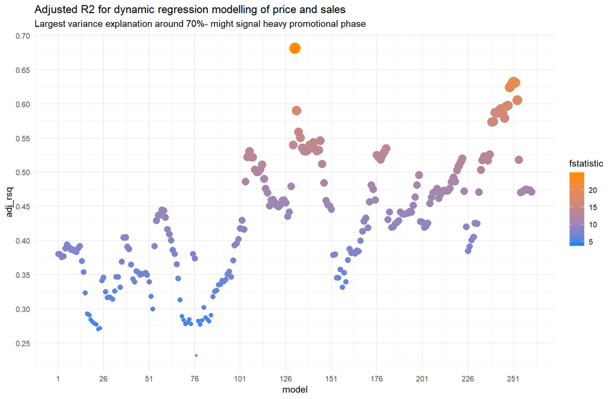

```r
rolling_tuna_lm <- function(start, end){
  tuna_sales_lm <- lm(log_sales ~ lprice_starkist + lprice_cs +
                        lprice_bb_solid + lprice_bb_chunk + lprice_geisha +
                        lprice_bb_large + lprice_hh_chunk,
                      data = tuna_brands[start:end,])

  coef_pvalues <- summary(tuna_sales_lm)[4]
  coef_pvalues <- coef_pvalues$coefficients[2:8, 4]

  model_coef <- coef(tuna_sales_lm) %>%
    as.data.frame() %>%
    rename(price_coef = ".") %>%
    rownames_to_column(var = "brand") %>%
    filter(brand != "(Intercept)") %>%
    mutate(brand = rep(brand_names, each = 1),
           brand = factor(brand, levels = share_table$brand),
           coef_pvalue = round(coef_pvalues, 4),
           coef_significance = ifelse(coef_pvalue < .05,
                                      "significant", "not_significant"),
           model = rep(start, times = 7)) %>%
    select(model, everything())

  model_components <- list(tuna_lm = tuna_sales_lm,
                           coef = model_coef)

  return(model_components)
}

tuna_coef <- map2(start_period, end_period,
                     function(x, y) rolling_tuna_lm(start = x, end = y))

tuna_model_fit <- list(
  adj_rsq = map(1:length(start_period), function(x)
    summary(tuna_coef[[x]]$tuna_lm)$adj.r.squared),
  fstatistic = map(1:length(start_period), function(x)
    summary(tuna_coef[[x]]$tuna_lm)$fstatistic[1])
  ) %>% map_df(unlist) %>%
  mutate(model = seq(1, n(), 1)) %>%
  select(model, adj_rsq, fstatistic)

tuna_model_fit %>%
  ggplot(aes(model, adj_rsq, size = fstatistic, colour = fstatistic)) +
  geom_point() +
  scale_x_continuous(breaks = seq(1, 300, 25)) +
  scale_y_continuous(breaks = seq(0, 1, .05)) +
  scale_size_continuous(guide = F) +
  scale_colour_gradient(low = "dodgerblue2", high = "darkorange") +
  labs(title = "Adjusted R2 for dynamic regression modelling of price and sales",
       subtitle = "Largest variance explanation around 70%- might signal heavy promotional phase")
```

The main reason I wanted to develop these models though was to review the coefficient changes. Below, I’ve included each brands coefficient values plotted over the 261 models with colouring for significance. Another piece of the competitive landscape becomes evident here, namely which brand prices are consistently significant, and thereby associated with total log sales, over time.

For example, every Chicken of the Sea coefficient is significant. This bolsters the idea that the brand might be influential pushing the category pricing structure. I previously suggested they might be a first mover, as was first suggested when examining their price and sales correlations, and this intuition is furthered here. In the same vein, Bumble Bee large has very few significant coefficients and therefore, does not have a strong association with total category sales.

While this doesn’t correct for the Yule-Simpson effect, which likely causes the cross elasticity sign changes, I think this adds another interpretable dimension for the competitive analysis.

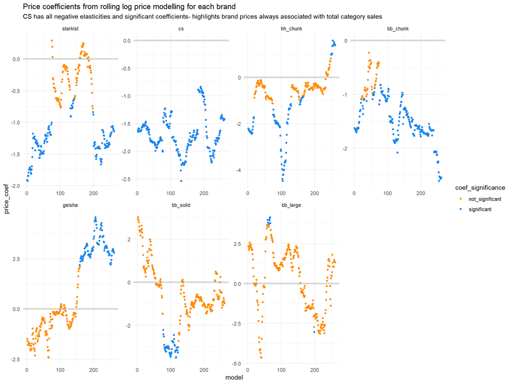

```r
rolling_tuna_coef <- map_df(1:length(start_period), function(x) tuna_coef[[x]]$coef)

rolling_tuna_coef %>%
  ggplot(aes(model, price_coef, colour = coef_significance)) +
  geom_point(size = 1.3) +
  geom_hline(yintercept = 0, size = 1.5, alpha = .4, colour = "darkgray") +
  facet_wrap(facets = "brand", scales = "free", nrow = 2) +
  scale_colour_manual(values = c("darkorange", "dodgerblue2")) +
  labs(title = "Price coefficients from rolling log price modelling for each brand",
       subtitle = "CS has all negative elasticities and significant coefficients- highlights brand prices always associated with total category sales")
```

Additionally, because the modelling approach yields numerous elasticities, their median value can be derived. I think these are better for interpreting how each brand is affecting the overall segment because there is a time dimension being added. Chicken of the Sea has the most impactful median elasticity. The coefficient indicates that for every percentage increase in brand price, total category sales go down about 1.76%. Once again, the higher volume brands all have the most impactful elasticities here.

This approach also corrected for Geisha’s positive elasticity. The -.14 seems to conform to the brand being a more specialty offering with higher prices and lower volume as well. However, the Bumble Bee large coefficient is still positive. This might indicate that for every unit increase in brand price, total category sales go up slightly because consumers prefer smaller lower cost cans. While this seems plausible, the modelling approach is known for this limitation, so I’m still skeptical of the median elasticity here.

```r
cross_medians <- rolling_tuna_coef %>%
  group_by(brand) %>%
  summarise(median_lm_coef = median(price_coef))

cross_medians %>%
  arrange(median_lm_coef) %>%
  custom_kable()
```

| brand | median_lm_coef |
| --- | --- |
| cs | -1.7563449 |
| bb_chunk | -1.5040792 |
| starkist | -1.0676016 |
| bb_solid | -0.8180092 |
| hh_chunk | -0.5814441 |
| geisha | -0.1480241 |
| bb_large | 0.8752870 |

### Final competitive mapping

The preceding analysis has provided comprehensive insights which can be used to better understand the tuna category’s competitive structure. As a final step, I’m putting together several of the findings so the structure is more clear. Below, the table includes volume, share, price, and elasticity metrics for each brand.

This long standing dominance is crucial to understanding the competitive landscape, especially in the high volume group. Direct competitors Chicken of the Sea and Bumble Bee chunk have smaller volume and share but, seem to be leaders in the pricing structure. This concept was reinforced during the multivariate log pricing modelling.

Chicken of the Sea has a significant elasticity in every rolling total log sales pricing model while Bumble Bee chunk had about 85% significant coefficients. I think this indicates both brands have a strong influence on the pricing direction but, that Starkist adjusts to accommodate this while still benefiting from established brand recognition. The fourth member of this group, HH chunk, seems to be a more upstart brand with lower prices but, less influence over the total category as seen in lower median cross elasticities and significant cross elasticities.

In the low volume, high cost group, further competition nuance is apparent when examining the metrics table. As has been established, Bumble Bee large is the highest price brand. Across all the brands represented, I think it’s the most unique offering making it a more niche product. As a result of this, it has very little influence over the total category.

```r
cross_elasticity_table <- rolling_cross_coefs %>%
  filter(cross_median < -2) %>%
  rename(median_elasticity = cross_median) %>%
  select(brand, median_elasticity)

tuna_competition <- rolling_tuna_coef %>%
  filter(coef_significance == "significant") %>%
  count(brand, sort = T) %>%
  mutate(percent_sig = round(n / length(start_period), 4) * 100) %>%
  select(-n) %>%
  inner_join(x = ., y = volume_table, by = "brand") %>%
  inner_join(x = ., y = price_table, by = "brand") %>%
  inner_join(x = ., y = share_table, by = "brand") %>%
  inner_join(x = ., y = cross_elasticity_table, by = "brand") %>%
  inner_join(x = ., y = cross_medians, by = "brand") %>%
  rename(lm_coef_sig = percent_sig,
         median_share = brand_share_median) %>%
  select(brand, median_volume, median_price, median_share,
         median_elasticity, lm_coef_sig, median_lm_coef)

tuna_competition %>%
  arrange(desc(median_volume)) %>%
  custom_kable()
```

| brand | median_volume | median_price | median_share | median_elasticity | lm_coef_sig | median_lm_coef |
| --- | --- | --- | --- | --- | --- | --- |
| starkist | 10801.0 | 0.82 | 25.40 | -4.678072 | 57.85 | -1.0676016 |
| cs | 6633.0 | 0.82 | 14.54 | -5.646288 | 100.00 | -1.7563449 |
| hh_chunk | 6315.0 | 0.75 | 14.05 | -4.192702 | 37.16 | -0.5814441 |
| bb_chunk | 6215.5 | 0.82 | 13.76 | -5.341210 | 84.67 | -1.5040792 |
| geisha | 2617.5 | 1.48 | 5.38 | -5.161486 | 39.46 | -0.1480241 |
| bb_solid | 2537.5 | 1.77 | 5.06 | -5.737040 | 17.62 | -0.8180092 |
| bb_large | 1044.5 | 3.40 | 2.10 | -3.726415 | 3.07 | 0.8752870 |

This competitive landscape can be visualized using a quadrant plot. Here, I’ve plotted the log price and sales and created the quadrant by including the median for each variable. This makes four groups:

- high cost, high volume
- high cost, low volume
- low cost, low volume
- low cost, high volume

As seen, and explained in the last table, the brands here fall into only two groups. The previous insights from the metrics table are more clear here. Bumble Bee large is the most unique brand with low influence and elasticity, Bumble Bee solid and Geisha directly compete in the more luxurious high cost market with high elasticities, Bumble Bee chunk, HH chunk, and Chicken of the sea are locked in a competitive low cost group trying to influence the category to combat Starkist’s brand dominance. The visualization helps bolster the exploratory and modelling phase by putting the major insights into one place.

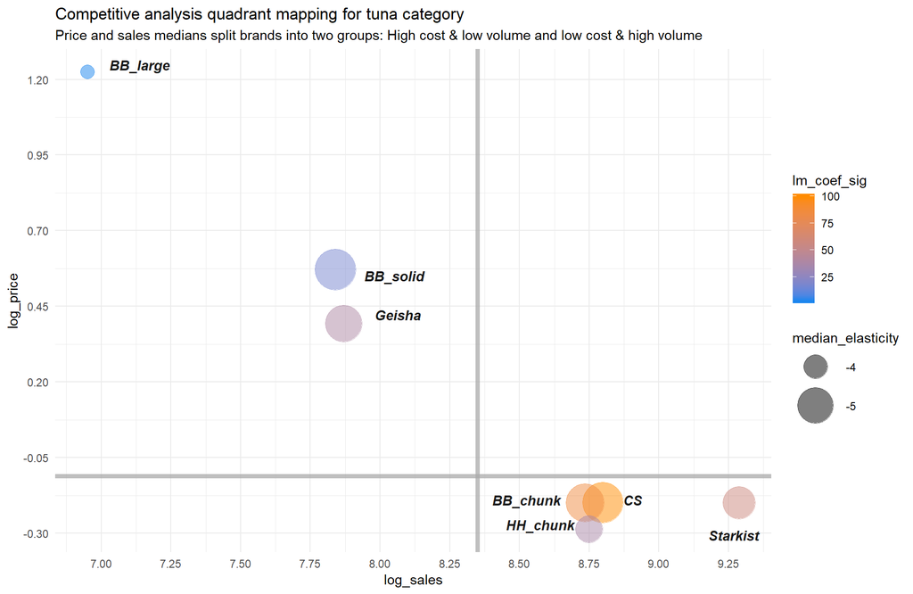

```r
tuna_competition %>%
  mutate(median_elasticity = median_elasticity * -1,
         log_price = log(median_price),
         log_sales = log(median_volume)) %>%
  ggplot(aes(log_sales, log_price, label = brand,
             size = median_elasticity, colour = lm_coef_sig)) +
  geom_point(alpha = .5) +
  annotate(geom = "text", label = "BB_large", colour = "gray10", fontface = 4,
           x = -Inf, y = Inf, hjust = -.9, vjust = 2) +
  annotate(geom = "text", label = "BB_solid", colour = "gray10", fontface = 4,
           x = 7.75, y = .5, hjust = -.9, vjust = -1) +
  annotate(geom = "text", label = "Geisha", colour = "gray10", fontface = 4,
           x = 7.75, y = .5, hjust = -1.4, vjust = 2.75) +
  annotate(geom = "text", label = "Starkist", colour = "gray10", fontface = 4,
           x = Inf, y = -Inf, hjust = 1.25, vjust = -1.15) +
  annotate(geom = "text", label = "BB_chunk", colour = "gray10", fontface = 4,
           x = 8.55, y = -.19, hjust = .6, vjust = .5) +
  annotate(geom = "text", label = "HH_chunk", colour = "gray10", fontface = 4,
           x = 8.55, y = -.19, hjust = .4, vjust = 2.85) +
  annotate(geom = "text", label = "CS", colour = "gray10", fontface = 4,
           x = 8.85, y = -.19, hjust = -.35, vjust = .5) +
  geom_vline(xintercept = median(log(tuna_sales$sales)), size = 1.75,
             alpha = .75, colour = "darkgray") +
  geom_hline(yintercept = median(log(tuna_prices$price)), size = 1.75,
             alpha = .75, colour = "darkgray") +
  scale_size_continuous(range = c(5, 15),
                        breaks = c(3, 4, 5),
                        labels = c(-3, -4, -5)) +
  scale_colour_gradient(low = "dodgerblue2", high = "darkorange") +
  scale_y_continuous(breaks = seq(-.3, 2, .25)) +
  scale_x_continuous(breaks = seq(6, 11, .25)) +
  labs(title = "Competitive analysis quadrant mapping for tuna category",
       subtitle = "Price and sales medians split brands into two groups: High cost & low volume and low cost & high volume")
```

### Analysis limitations

While the pricing models and wider competitive analysis is robust, this approach comes with limitations. The resulting price elasticities are constant and therefore uniform across time and brand when using simple linear models. This assumption is debatable but, without any nuanced knowledge of the canned tuna segment, I think the approach is still reasonable.

When using the multivariate log pricing modelling approach, the resulting cross price elasticities have a tendency to switch signs, which happens with Bumble Bee large and Geisha, among others. This is contrary to any microeconomic theory and, more generally, doesn’t make business sense. As a result, the model interpretation suffers. That said, I tried to reduce this issue with the dynamic modelling so the cross elasticities could be reviewed across many models so a median could be derived. While not a perfect solution, I think it helps alleviate some of the multivariate modelling limitations.

More widely, I tried to conduct a robust exploratory analysis so there was an empirical base for better understanding the category dynamic. I think the data set is missing crucial data on seasonality, promotional activity, and actual date times. These hinder the analysis because they are likely influential on the initial volume, share, and prices. To overcome this, I provided a thorough review and provided my intuition and extrapolations from the results. The combination of the modelling work and this exploratory phase help illuminate the category’s competitive workings, which I’ve done to address both sections limitations.

### References

#### 1. Berman et. al, “Simpson’s Paradox: a cautionary tale in advanced analytics”

#### Access: https://www.statslife.org.uk/the-statistics-dictionary/2012-simpson-s-paradox-a-cautionary-tale-in-advanced-analytics